# Lab 5: MATH 4753

Andrew Douglass

2024-09-20

#Tasks

## Task 1

```r
getwd()
```

```
## [1] "C:/RPACKAGES/FALL24DOUG0060/labs/Lab 5"
```

## Task 2

### 100 Iterations

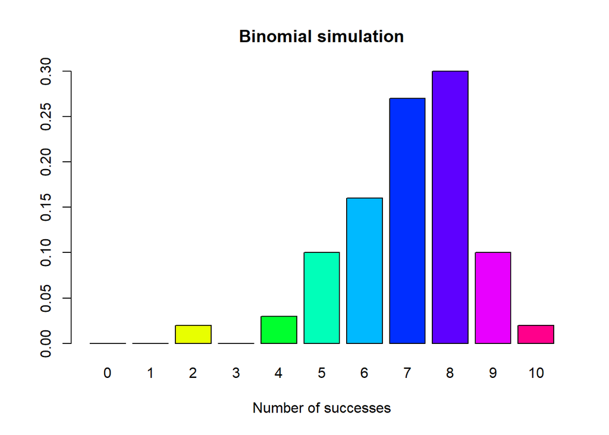

```r
mybin=function(iter=100,n=10, p=0.7){
# This is the function that will simulate a binomial distribution
# The top portion is adjustable when the function is called
# iter is for the number of iterations, n is for the sample, and p is the probability
sam.mat=matrix(NA,nr=n,nc=iter, byrow=TRUE)
# This part creates a matrix to hold the samples
succ=c()
for( i in 1:iter){
# Using the empty vector the for loop goes through the iterations
sam.mat[,i]=sample(c(1,0),n,replace=TRUE, prob=c(p,1-p))
succ[i]=sum(sam.mat[,i])
}
# Success is based on p while the failures are based on 1-p
# The successes are tracked and the following will create a table of the successes
succ.tab=table(factor(succ,levels=0:n))
barplot(succ.tab/(iter), col=rainbow(n+1), main="Binomial simulation", xlab="Number of successes")
# This will create a barplot of the proportions of the successes
succ.tab/iter
}
bin100 = mybin(iter=100,n=10, p=0.7)
```

### 200 Iterations

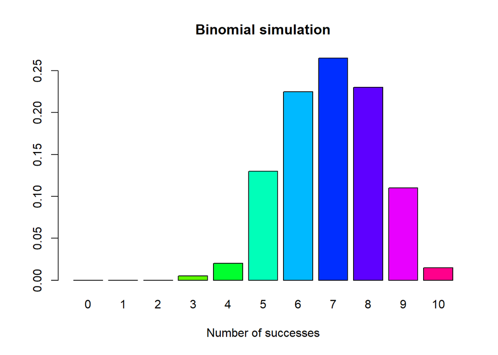

```
##
##     0     1     2     3     4     5     6     7     8     9    10
## 0.000 0.000 0.000 0.005 0.020 0.130 0.225 0.265 0.230 0.110 0.015
```

```r
mybin(iter=200,n=10, p=0.7)
```

### 500 Iterations

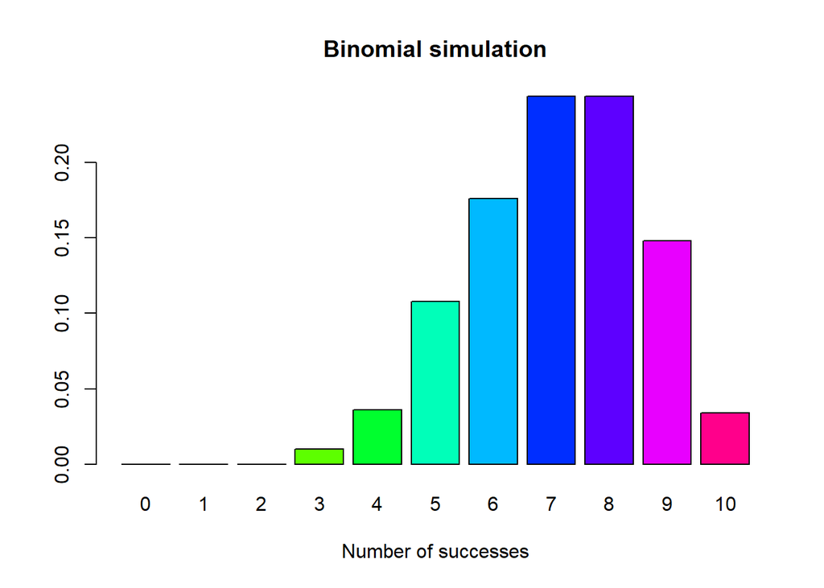

```
##
##     0     1     2     3     4     5     6     7     8     9    10
## 0.000 0.000 0.000 0.010 0.036 0.108 0.176 0.244 0.244 0.148 0.034
```

```r
mybin(iter=500,n=10, p=0.7)
```

### 1000 Iterations

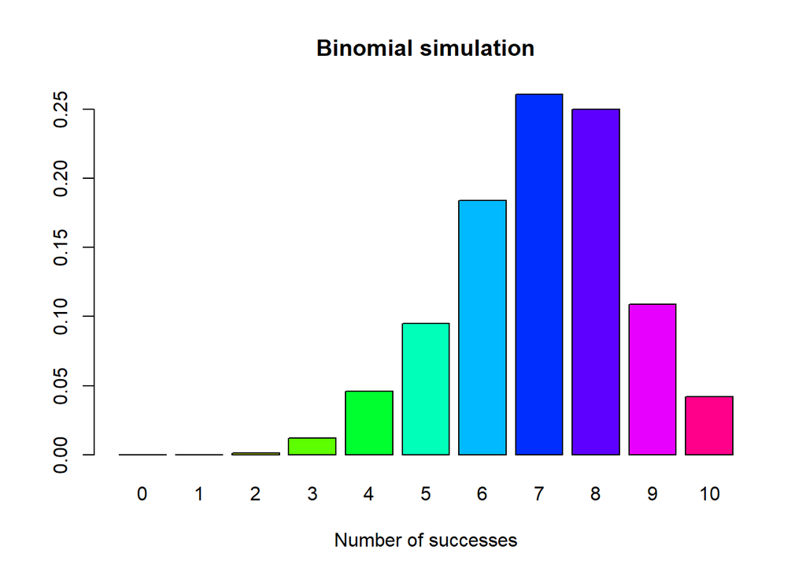

```
##
##     0     1     2     3     4     5     6     7     8     9    10
## 0.000 0.000 0.001 0.012 0.046 0.095 0.184 0.261 0.250 0.109 0.042
```

```r
mybin(iter=1000,n=10, p=0.7)
```

### 10000 Iterations

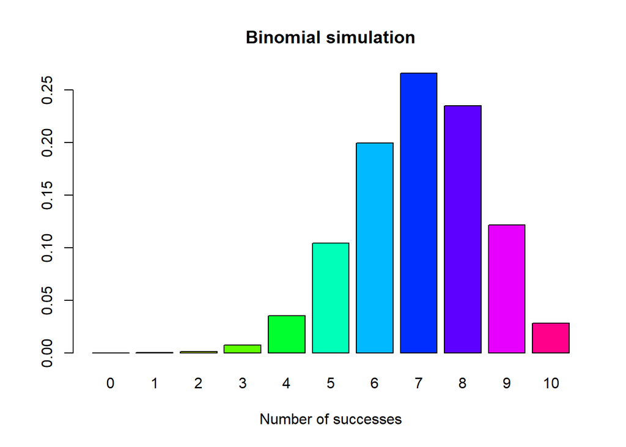

```
##
##      0      1      2      3      4      5      6      7      8      9     10
## 0.0000 0.0002 0.0013 0.0076 0.0354 0.1046 0.1997 0.2662 0.2352 0.1218 0.0280
```

```r
mybin(iter=10000,n=10, p=0.7)
```

```r
dbin.tab = round(dbinom(0:10, size = 10, prob = 0.7), 4)
names(dbin.tab) = 0:10
dbin.tab
```

```
##      0      1      2      3      4      5      6      7      8      9     10
## 0.0000 0.0001 0.0014 0.0090 0.0368 0.1029 0.2001 0.2668 0.2335 0.1211 0.0282
```

## Task 3

### No replacement

```r
sample(c(1, 1, 1, 1, 1, 1, 1, 1, 1, 1, 1, 1, 0, 0, 0, 0, 0, 0, 0, 0), size = 5, replace = FALSE, prob = NULL)
```

```
## [1] 0 1 1 1 1
```

### With Replacement

```r
sample(c(1, 1, 1, 1, 1, 1, 1, 1, 1, 1, 1, 1, 0, 0, 0, 0, 0, 0, 0, 0), size = 5, replace = TRUE, prob = NULL)
```

```
## [1] 0 1 1 0 0
```

### Using function myhyper()

```r
myhyper = function(iter = 100, N = 20, r = 12, n = 5){

  sam.mat = matrix(NA, nrow = n, ncol = iter, byrow = TRUE)

  successes = c()

  for(i in 1:iter){

    sam.mat[, i] = sample(rep(c(1, 0), c(r, N - r)), n, replace = FALSE)

    successes[i] = sum(sam.mat[, i])

  }

  success.tab = table(factor(successes, levels = 0:n))

  iter.lab = paste0("iter = ", iter)
  N.lab = paste0("N = ", N)
  r.lab = paste0("r = ", r)
  n.lab = paste0("n = ", n)
  lab = paste(iter.lab, N.lab, r.lab, n.lab, sep = ", ")
  barplot(success.tab/(iter), col = rainbow(n + 1), main = "Hypergeometric Simulation", sub = lab, xlab = "Number of Successes")
  success.tab / iter
}
```

### 100 Iterations

```r
myhyper1 = myhyper(iter = 100, N = 20, r = 12, n = 5)
```

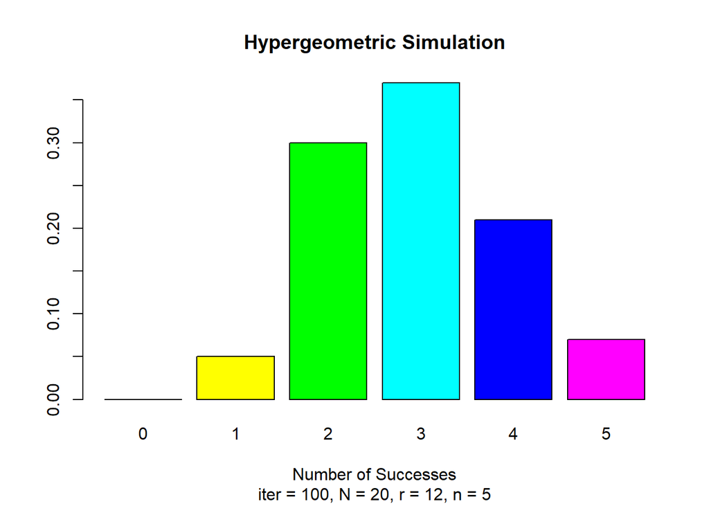

### 200 Iterations

```r
myhyper2 = myhyper(iter = 200, N = 20, r = 12, n = 5)
```

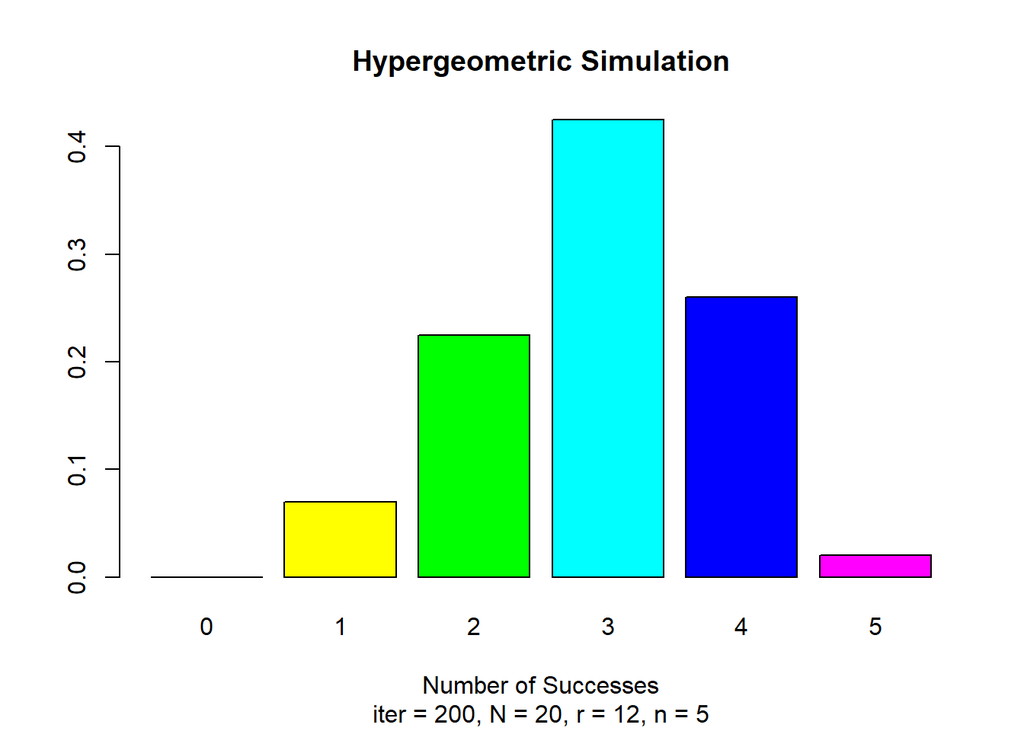

### 500 Iterations

```r
myhyper3 = myhyper(iter = 500, N = 20, r = 12, n = 5)
```

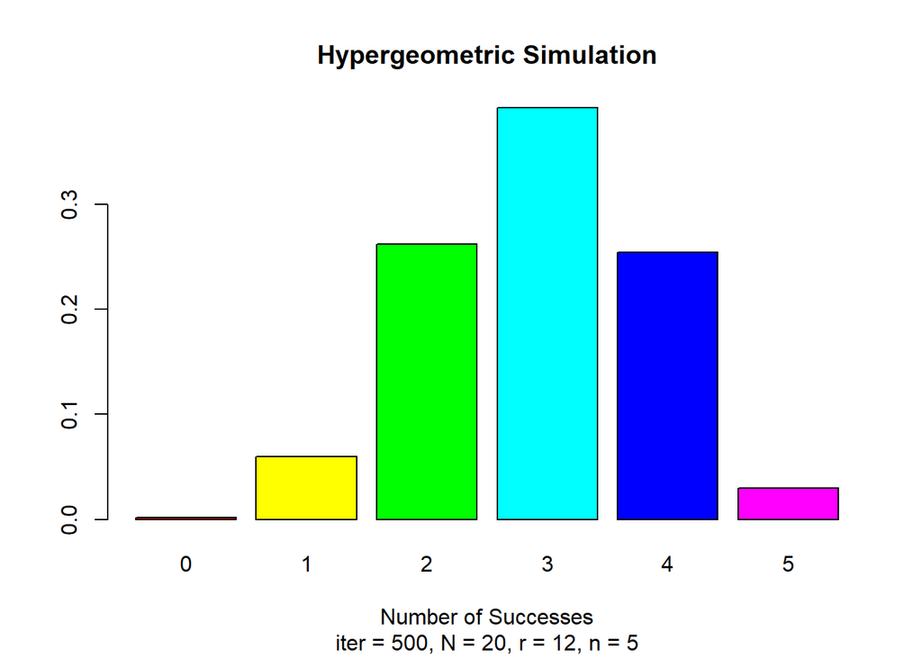

### 1000 Iterations

```r
myhyper4 = myhyper(iter = 1000, N = 20, r = 12, n = 5)
```

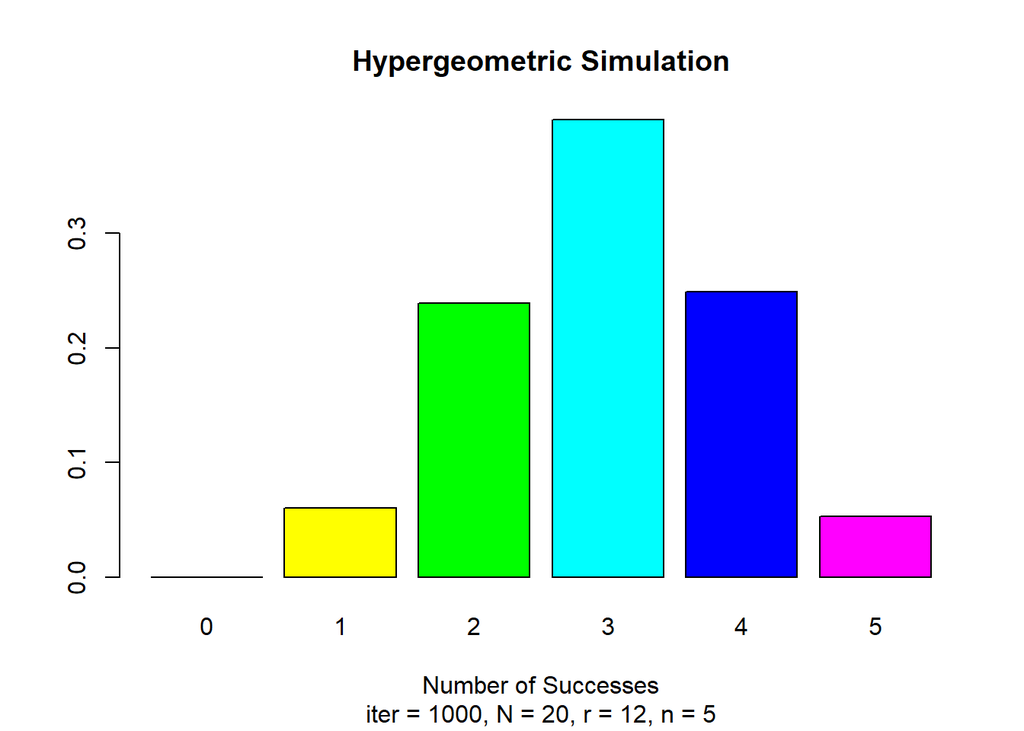

### 10000 Iterations

```r
myhyper5 = myhyper(iter = 10000, N = 20, r = 12, n = 5)
```

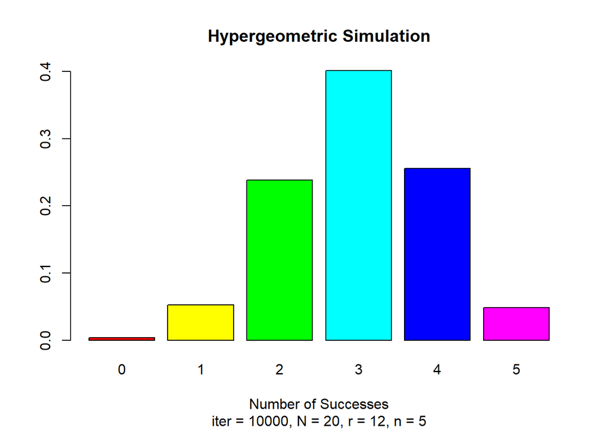

### Verifying using dhyper()

```r
dhyper.tab = round(dhyper(x = 0:5, m = 12, n = 8, k = 5), 4)
names(dhyper.tab) = 0:5
dhyper.tab
```

```
##      0      1      2      3      4      5
## 0.0036 0.0542 0.2384 0.3973 0.2554 0.0511
```

## Task 4

The code should be creating samples and uses factors to create barplots. It is something that could be implemented as a function for the package for use in part 6. Here is the following code to be reviewed:

```r
mysample=function(n, iter=10,time=0.5){
for( i in 1:iter){
#make a sample
s=sample(1:10,n,replace=TRUE)
# turn the sample into a factor
sf=factor(s,levels=1:10)
#make a barplot
barplot(table(sf)/n,beside=TRUE,col=rainbow(10),
main=paste("Example sample()", " iteration ", i, " n= ", n,sep="") ,
ylim=c(0,0.2)
)

#release the table
Sys.sleep(time)
}
}
```

This creates barplots based on the sample data. At the start of each iteration, a sample is taken from the numbers 1 to 10. The sample is then turned into a factor and a barplot is created. The table is then released after a certain amount of time. These are basically pauses built in.

### Running the Function

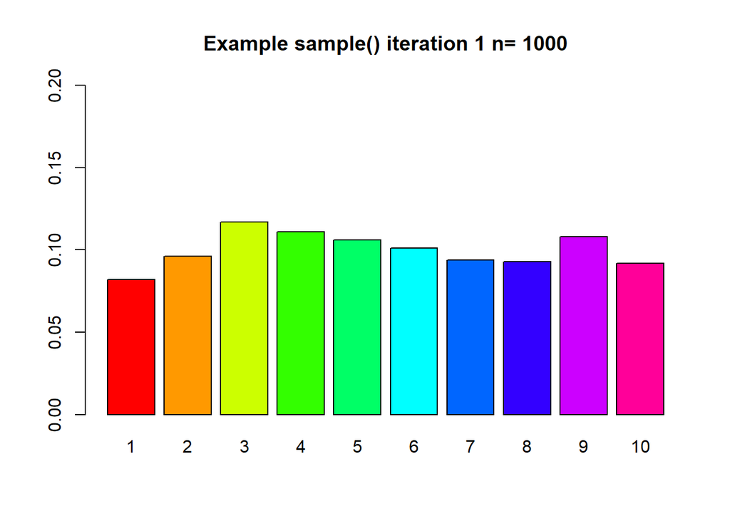

```r
mysample(n = 1000, iter = 1, time = 1)
```

## Task 5

```r
choose(8, 4)
```

```
## [1] 70
```

```r
print("Result for choose(8, 4)")
```

```
## [1] "Result for choose(8, 4)"
```

```r
1 - ppois(q = 3, lambda = 2)
```

```
## [1] 0.1428765
```

```r
print("Result for 1 - ppois(q = 3, lambda = 2)")
```

```
## [1] "Result for 1 - ppois(q = 3, lambda = 2)"
```

```r
choose(10 - 1, 3 - 1) * 0.4^3 * (1 - 0.4)^(10 - 3)
```

```
## [1] 0.06449725
```

```r
print("Result for P(Y = 10), Y NegBin(p=0.4, r=3)")
```

```
## [1] "Result for P(Y = 10), Y NegBin(p=0.4, r=3)"
```

```r
pbinom(8, 15, 0.4)
```

```
## [1] 0.9049526
```

```r
print("Result for pbinom(8, 15, 0.4)")
```

```
## [1] "Result for pbinom(8, 15, 0.4)"
```